# All gBlock data

copyright 2021 Mary Lesperance

2021-06-14

# 1 Instructions

This file recreates the analyses in the publication, ‘A Statistical Model for Calibration and Computation of Detection and Quantification Limits for Low Copy Number Environmental DNA samples’ by Lesperance, Allison, Bergman, Hocking, Helbing, *eDNA*, 2021.

- Create a folder called Outputs in your working directory.
- Put files in working directory: PoissonCalib-Functions-7April2021.R, GEDWG_LOD_DATA3.csv (Klymus data), AssaySummary-ML.csv (Klymus results)
- Data set csv file requirements. Columns: Target, Lab, Cq, Sq
- For nondetects, set Cq to be empty or NA value
- For negative controls, set Sq to be empty or 0 or NA value
- DO NOT DUPLICATE Target names over different Labs!!
- The script uses observations with nonempty data and where phat <1 (num detect<num technical replicates)
- Only the SQ’s up to the first one with phat==1 are used.
- Allows for variable numbers of SQ levels per Target.
- Assumes SQs == NA are zero, i.e. are negative controls.
- Adds in Negative Control (ntc) zeroes (24/(48 for Monroe) technical replicates).
- The code uses the R function optim. A convergence code 0 indicates successful completion.
- Ignore warnings if results are sensible.

# 2 Process/Summarize samples by Lab; Compute the Poisson estimates of SQ

Hindson et al “High-Throughput Droplet Digital PCR System for Absolute Quantitation of DNA Copy Number”, Anal. Chem., 2011, 83 (22), pp 8604–8610 use a Poisson approximation for quantitation. Before that, Dube et al. 2008, “Mathematical analysis of copy number variation in a DNA sample using digital PCR on a nanofluidic device”, POlS One, Vol 3, Issue 8, e2876, model the number of molecules in each chamber as a Poisson process, giving the relationship between $p$ and $\lambda$.

```
## [1] 300   6
```

```
## dim, before negative controls added
```

```
##      Target          SQ              detect            n
##  Hno    : 14   Min.   :      0   Min.   : 0.00   Min.   : 1.00
##  MYPI-6 : 12   1st Qu.:      2   1st Qu.: 8.00   1st Qu.:24.00
##  MYPI-6t: 12   Median :     50   Median :24.00   Median :24.00
##  eASMO9 : 10   Mean   :   8414   Mean   :27.73   Mean   :36.58
##  eASTR4 : 10   3rd Qu.:   1250   3rd Qu.:48.00   3rd Qu.:48.00
##  eFISH1 : 10   Max.   :1000000   Max.   :96.00   Max.   :96.00
##  (Other):232
##      Cqmean           Lab
##  Min.   :16.32   UVIC   :110
##  1st Qu.:29.06   Monroe : 79
##  Median :33.85   CERC   : 36
##  Mean   :33.02   UMESC  : 31
##  3rd Qu.:37.70   Lance  : 14
##  Max.   :47.20   Wilson : 14
##  NA's   :24      (Other): 16
```

```
## [1] 325  13
```

```
## dim, Added 24/48 negative controls for Targets with zero ntc
```

```
##
##
## Table: APHIS
##
## Target       SQ   detect    n    phat
## -------  ------  -------  ---  ------
## D-loop      0.0        0   24   0.000
## D-loop      0.1        7   48   0.146
## D-loop      0.5       18   47   0.383
## D-loop      1.0       33   48   0.688
## D-loop     10.0       48   48   1.000
## D-loop    100.0       48   48   1.000
##
##
## Table: CERC
```

[output cut: 358 more lines]

# 3 Plot the Poisson estimates (and CI) of SQ for levels that had non-detects

Only the first levels of SQ that had non-detects are analyzed. Blue line is least squares linear regression line.

*ML* ??will error if all phats==1

```
##
##
## Too few values for  CID
```

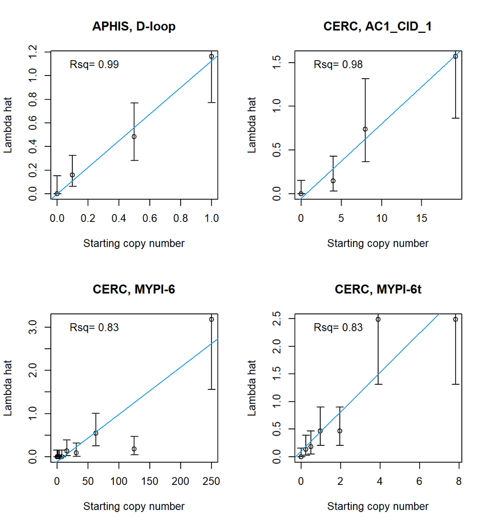

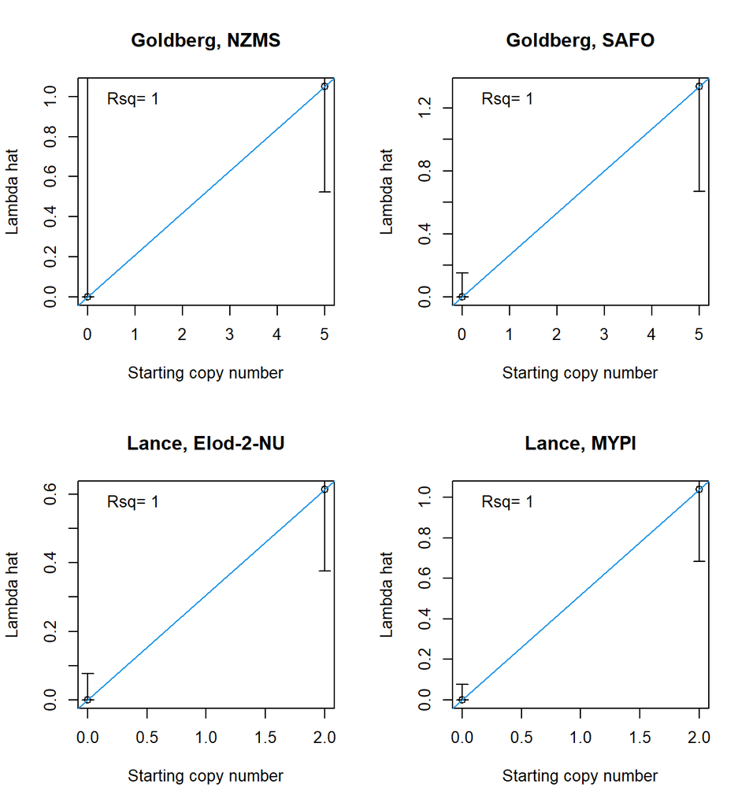

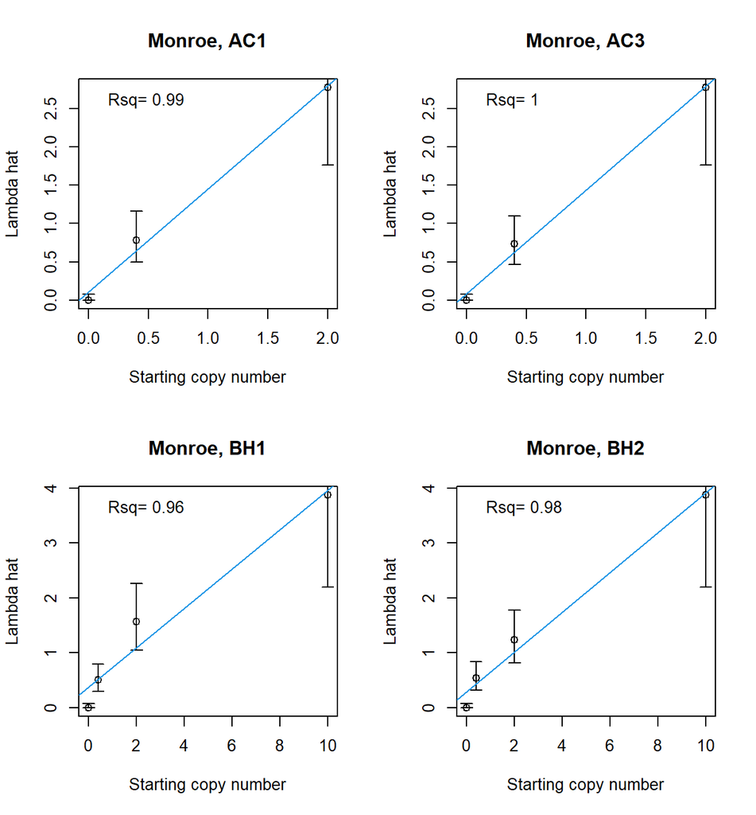

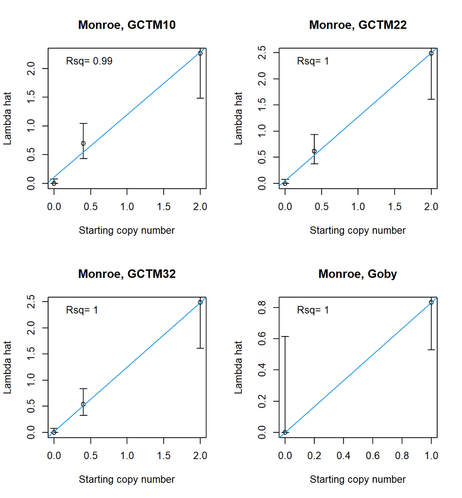

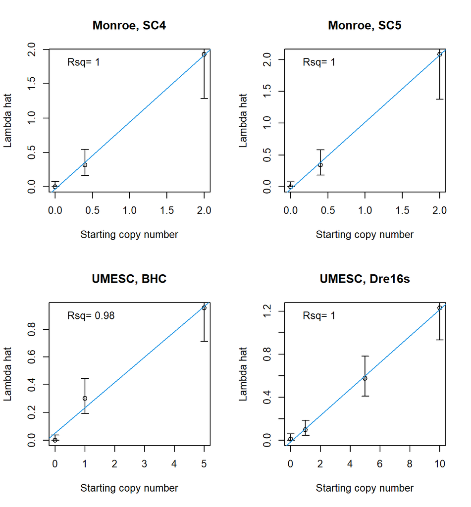

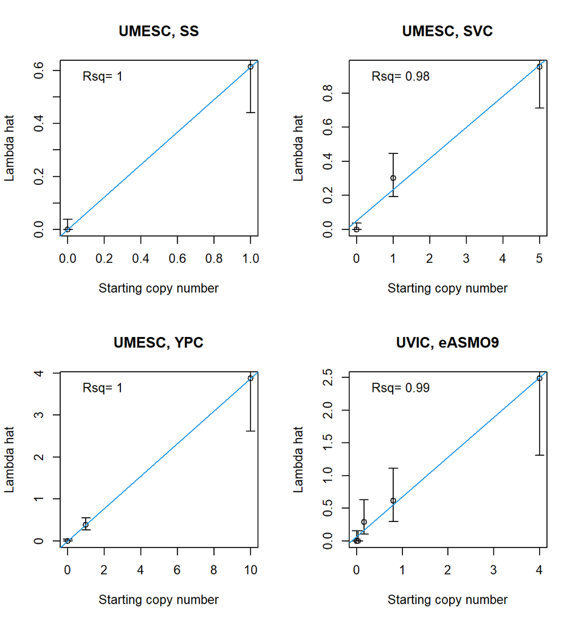

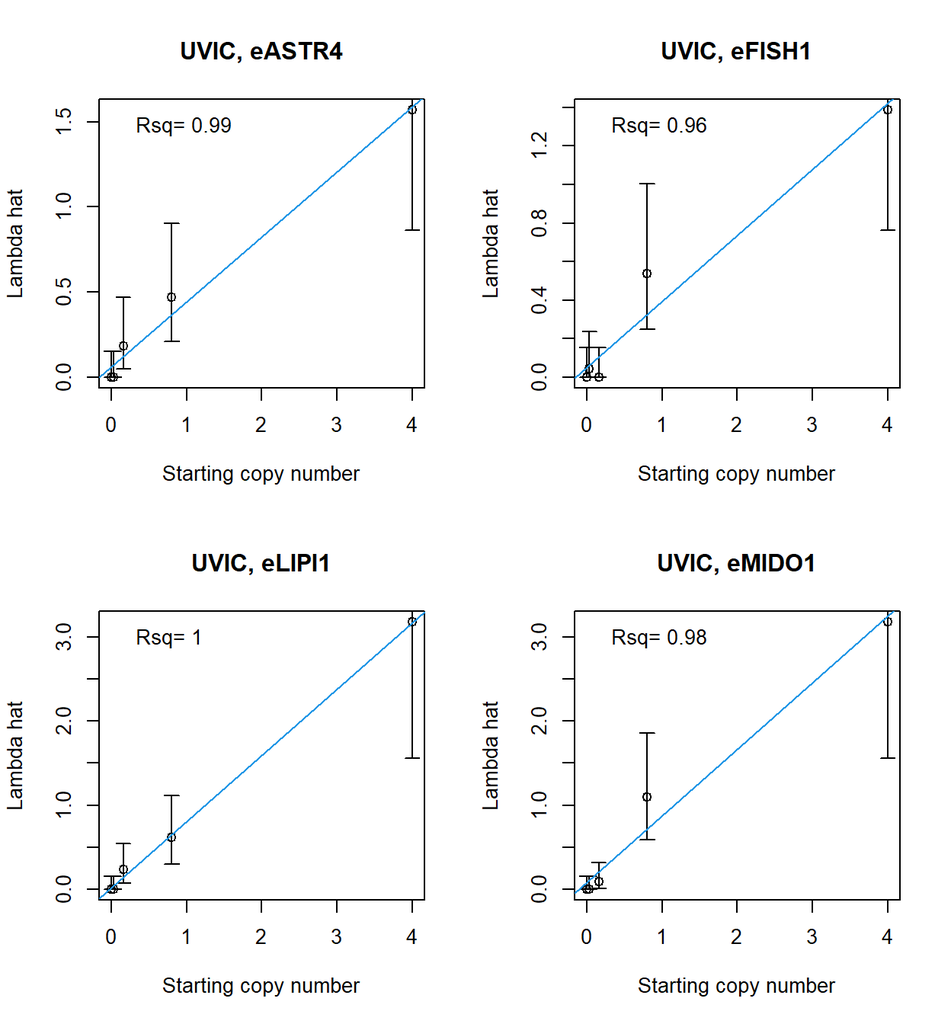

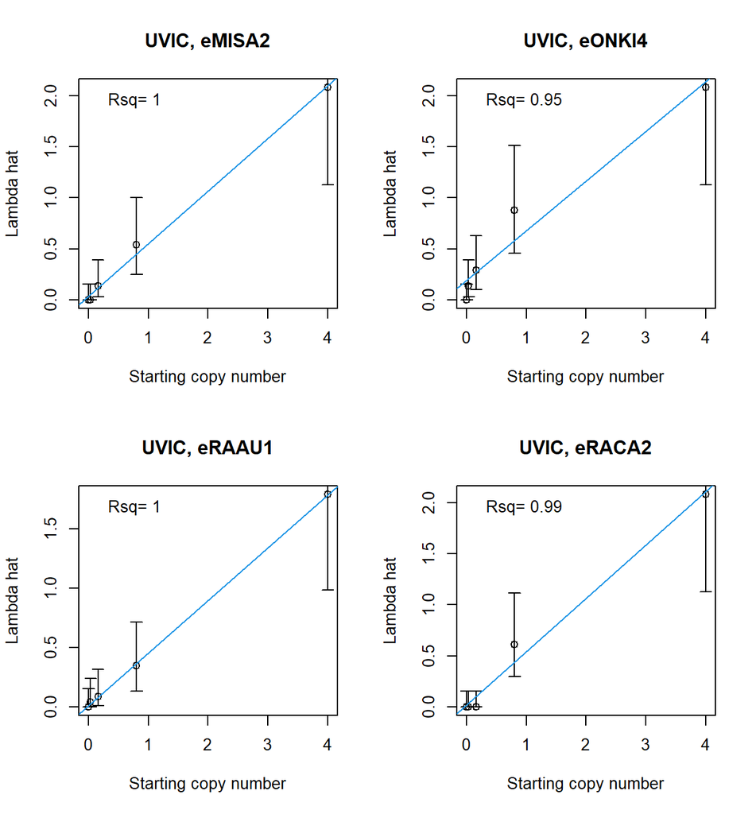

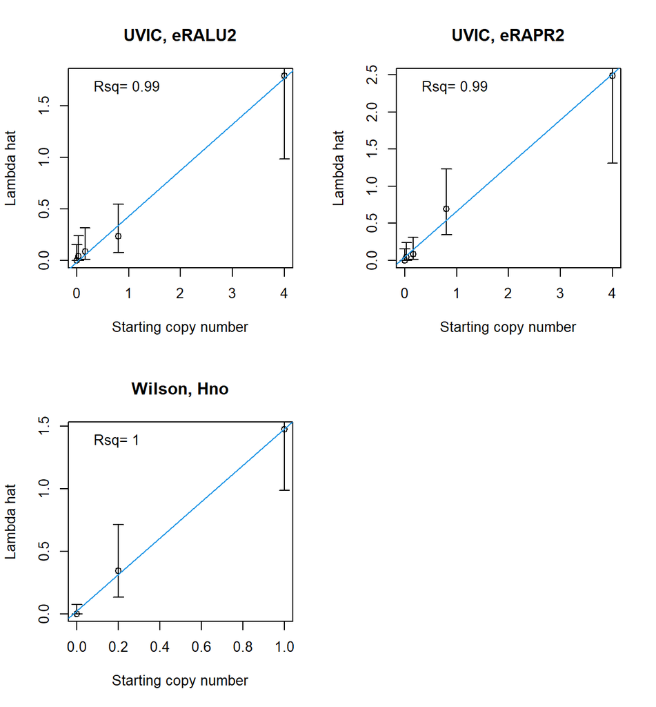

# 4 Supplemental Material

# 5 Estimate Poisson models - no intercept model

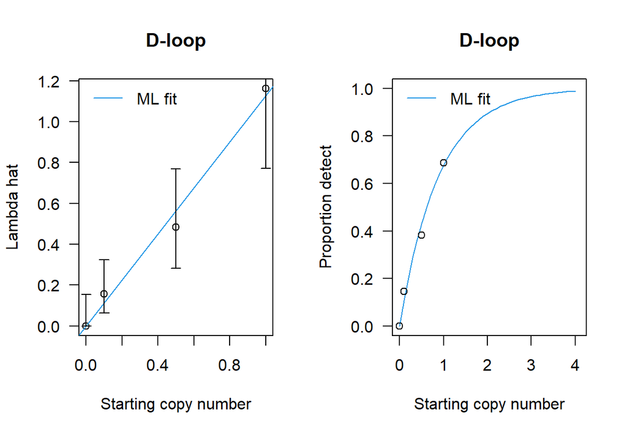

```
##
##
##
##
##  D-loop
## Convergence= 0
##      Estimate Std.Err Z value  Pr(>z)
## beta    1.126   0.153    7.37 1.8e-13 ***
## ---
## Signif. codes:  0 '***' 0.001 '**' 0.01 '*' 0.05 '.' 0.1 ' ' 1
## LLR test stat= 1.17757 , df=  3 , p-value= 0.7583889
```

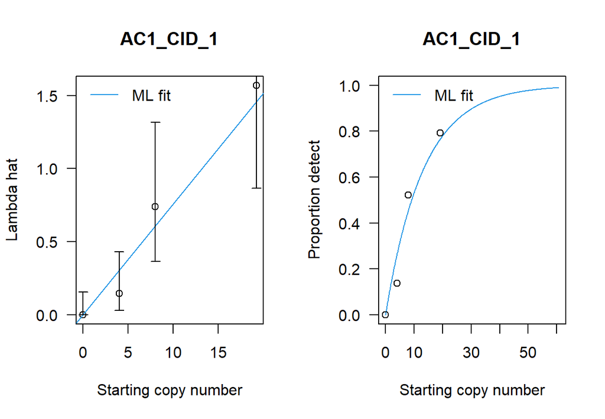

```
##
##
##
##
##  AC1_CID_1
## Convergence= 0
##      Estimate Std.Err Z value  Pr(>z)
## beta   0.0758  0.0137    5.53 3.2e-08 ***
## ---
## Signif. codes:  0 '***' 0.001 '**' 0.01 '*' 0.05 '.' 0.1 ' ' 1
## LLR test stat= 2.543745 , df=  3 , p-value= 0.4674373
##
## Too few values for  CID
```

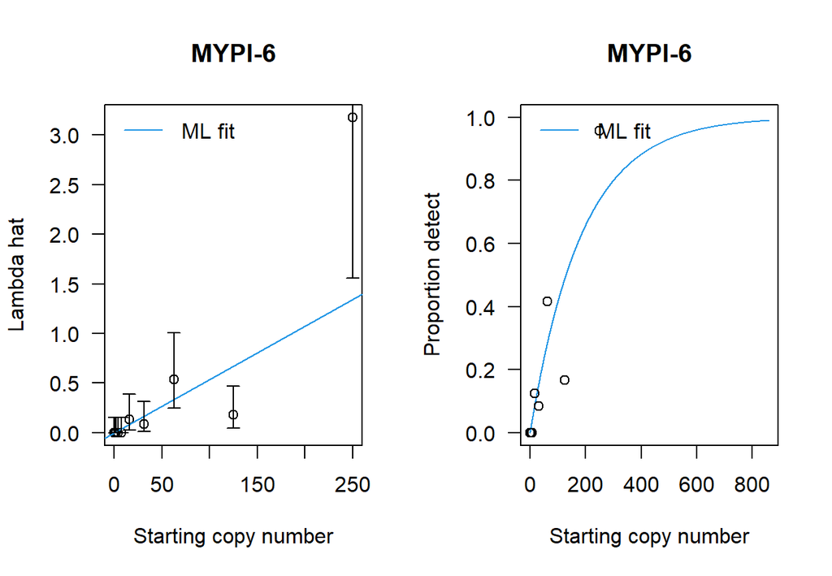

```
##
##
##
##
##  MYPI-6
## Convergence= 0
##      Estimate  Std.Err Z value  Pr(>z)
## beta 0.005363 0.000847    6.33 2.4e-10 ***
## ---
## Signif. codes:  0 '***' 0.001 '**' 0.01 '*' 0.05 '.' 0.1 ' ' 1
## LLR test stat= 26.74636 , df=  11 , p-value= 0.005018208
```

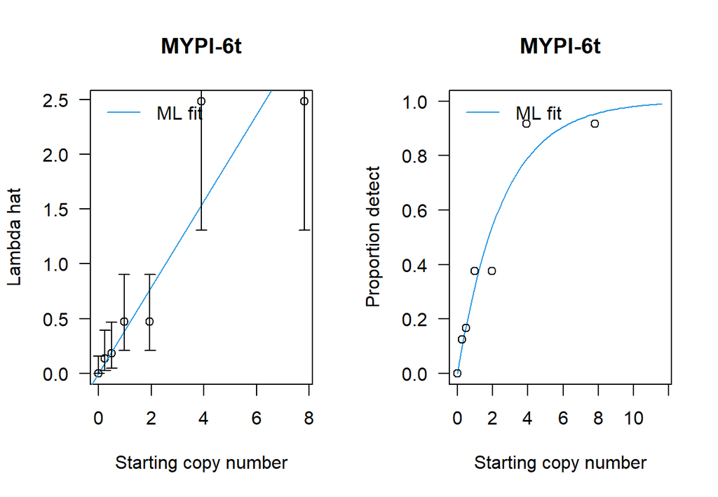

```
##
##
##
##
##  MYPI-6t
## Convergence= 0
##      Estimate Std.Err Z value  Pr(>z)
## beta    0.394   0.054    7.29 3.1e-13 ***
## ---
## Signif. codes:  0 '***' 0.001 '**' 0.01 '*' 0.05 '.' 0.1 ' ' 1
## LLR test stat= 6.787625 , df=  6 , p-value= 0.340935
##
## Too few values for  NZMS
## Too few values for  SAFO
## Too few values for  Elod-2-NU
## Too few values for  MYPI
```

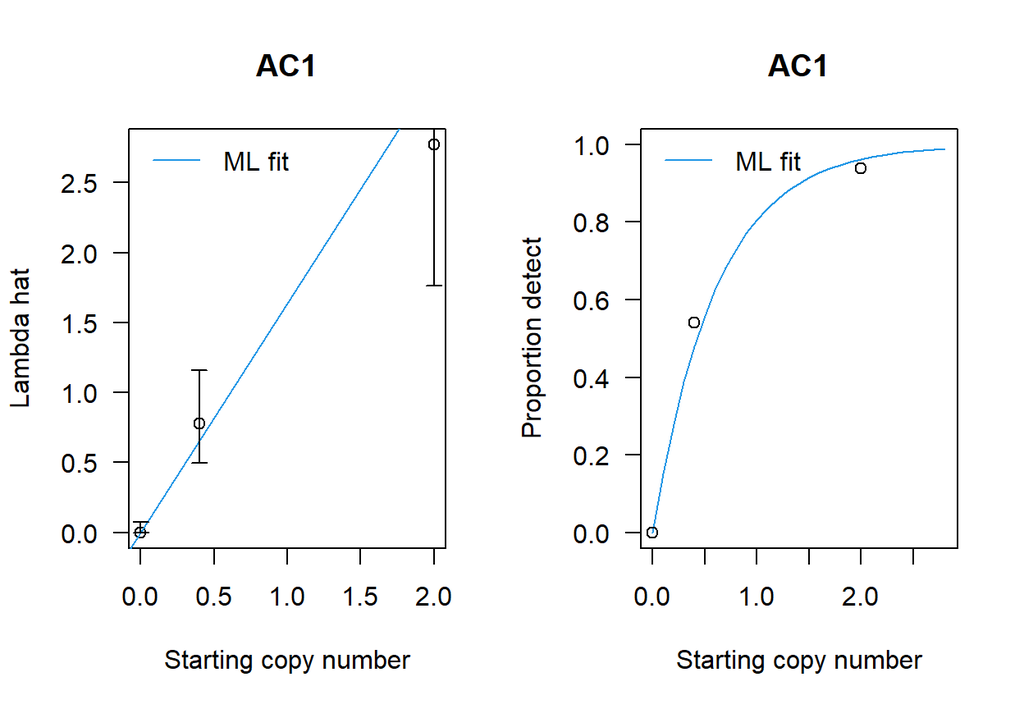

```
##
##
##
##
##  AC1
## Convergence= 0
##      Estimate Std.Err Z value  Pr(>z)
## beta    1.636   0.244     6.7 2.1e-11 ***
## ---
## Signif. codes:  0 '***' 0.001 '**' 0.01 '*' 0.05 '.' 0.1 ' ' 1
## LLR test stat= 1.393097 , df=  2 , p-value= 0.4983022
```

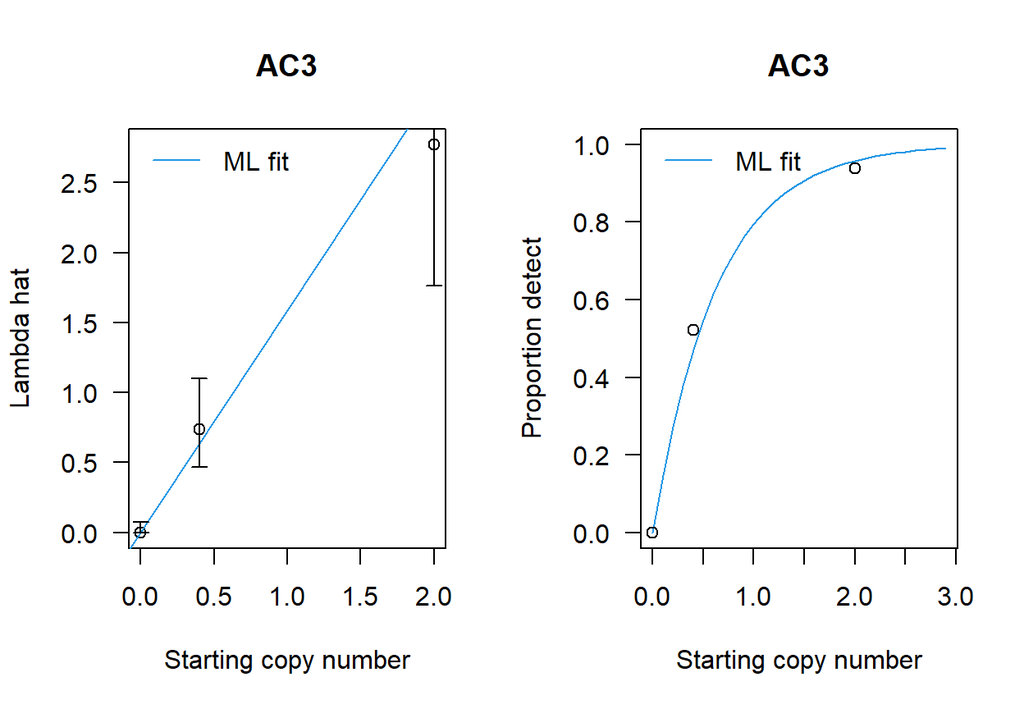

```
##
##
##
##
##  AC3
## Convergence= 0
##      Estimate Std.Err Z value  Pr(>z)
## beta    1.587   0.237     6.7 2.2e-11 ***
## ---
## Signif. codes:  0 '***' 0.001 '**' 0.01 '*' 0.05 '.' 0.1 ' ' 1
## LLR test stat= 0.9438297 , df=  2 , p-value= 0.6238066
```

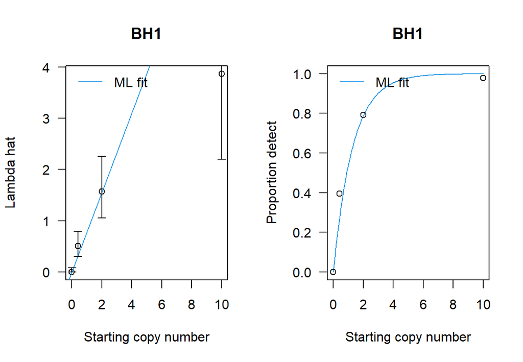

```
##
##
##
##
##  BH1
## Convergence= 0
##      Estimate Std.Err Z value Pr(>z)
## beta    0.775   0.108    7.16  8e-13 ***
## ---
## Signif. codes:  0 '***' 0.001 '**' 0.01 '*' 0.05 '.' 0.1 ' ' 1
## LLR test stat= 9.602954 , df=  3 , p-value= 0.02226096
```

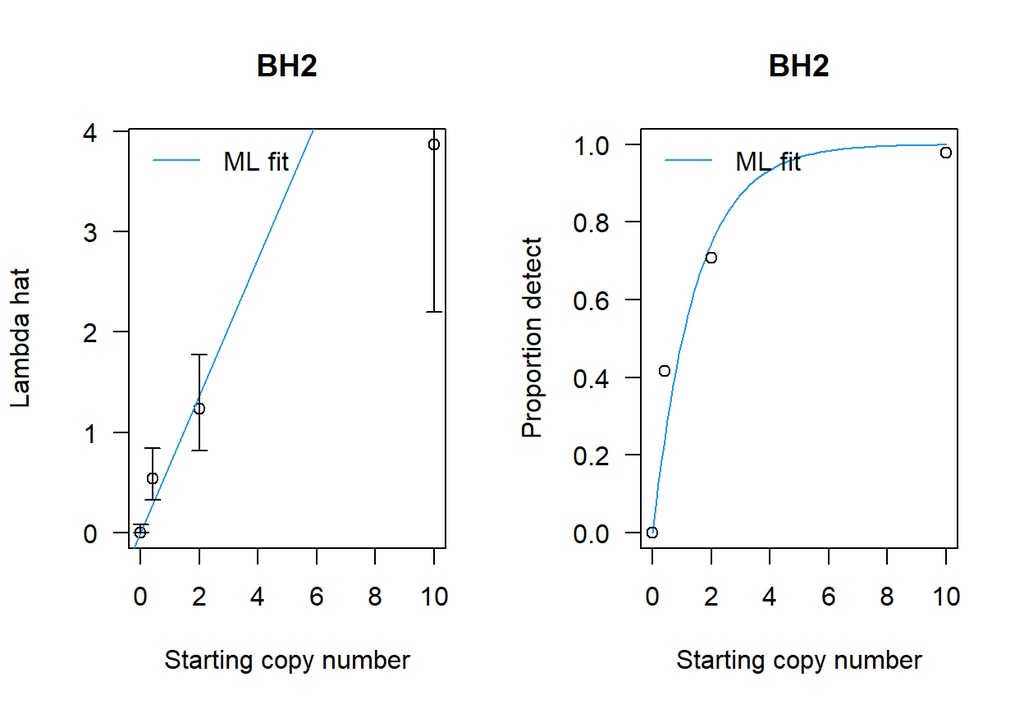

```
##
##
##
##
##  BH2
## Convergence= 0
##      Estimate Std.Err Z value  Pr(>z)
## beta   0.6836  0.0953    7.17 7.5e-13 ***
## ---
## Signif. codes:  0 '***' 0.001 '**' 0.01 '*' 0.05 '.' 0.1 ' ' 1
## LLR test stat= 11.70607 , df=  3 , p-value= 0.008460941
```

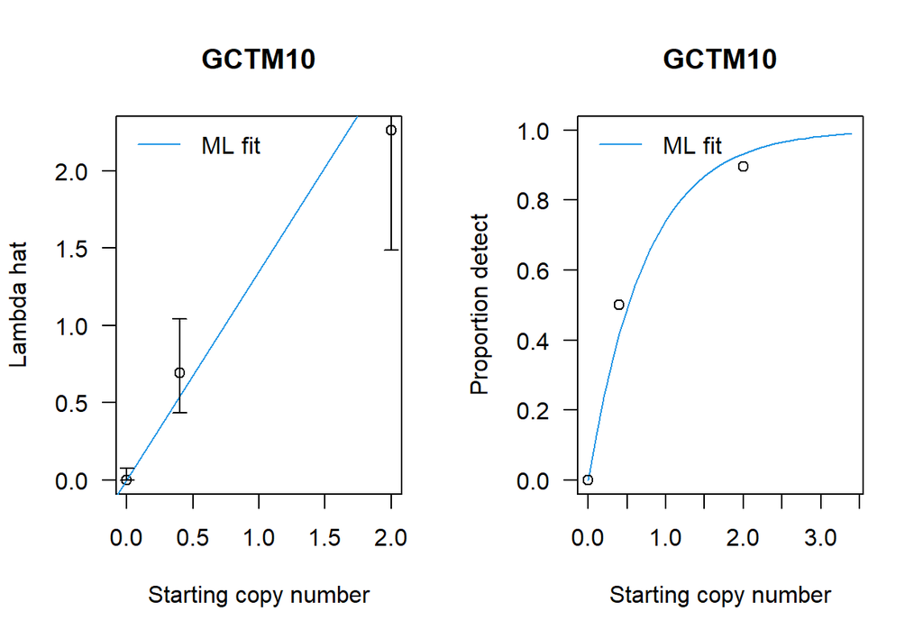

```
##
##
##
##
##  GCTM10
## Convergence= 0
##      Estimate Std.Err Z value  Pr(>z)
## beta    1.350   0.196     6.9 5.1e-12 ***
## ---
## Signif. codes:  0 '***' 0.001 '**' 0.01 '*' 0.05 '.' 0.1 ' ' 1
## LLR test stat= 2.23836 , df=  2 , p-value= 0.3265475
```

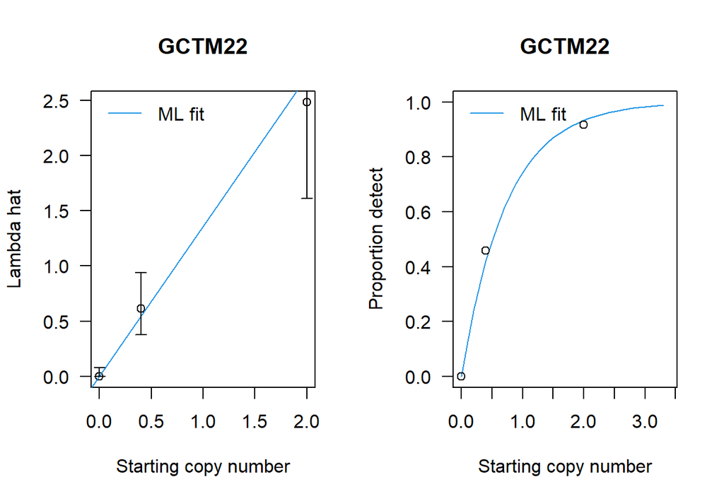

```
##
##
##
##
##  GCTM22
## Convergence= 0
##      Estimate Std.Err Z value  Pr(>z)
## beta     1.36    0.20    6.79 1.1e-11 ***
## ---
## Signif. codes:  0 '***' 0.001 '**' 0.01 '*' 0.05 '.' 0.1 ' ' 1
## LLR test stat= 0.5143054 , df=  2 , p-value= 0.7732501
```

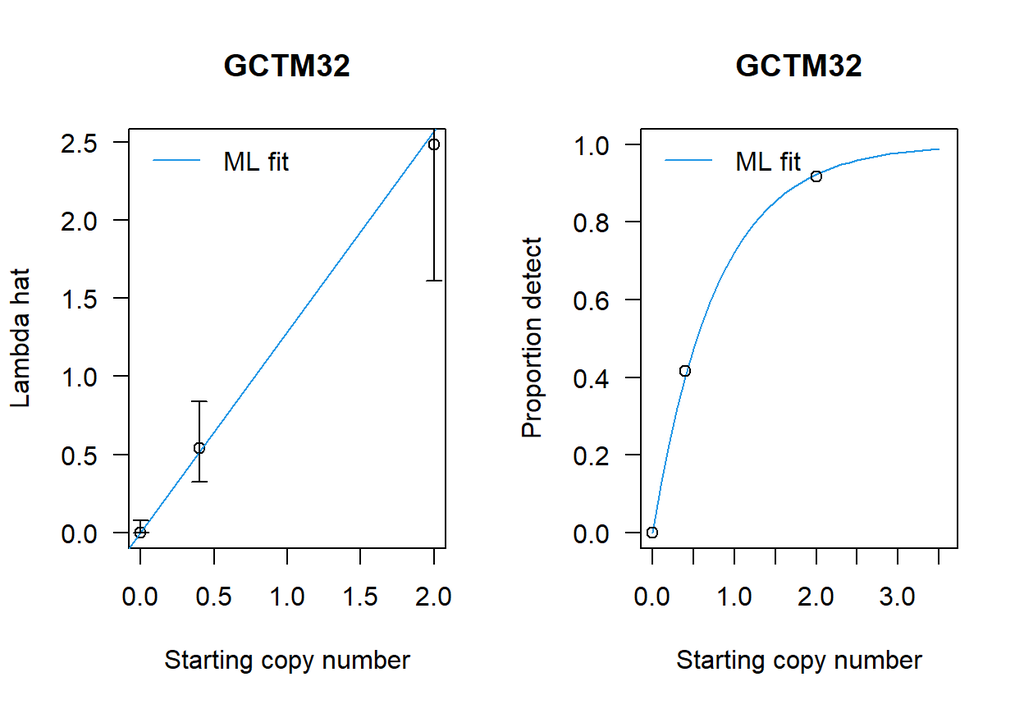

```
##
##
##
##
##  GCTM32
## Convergence= 0
##      Estimate Std.Err Z value  Pr(>z)
## beta     1.28    0.19    6.76 1.4e-11 ***
## ---
## Signif. codes:  0 '***' 0.001 '**' 0.01 '*' 0.05 '.' 0.1 ' ' 1
## LLR test stat= 0.07393266 , df=  2 , p-value= 0.9637086
##
## Too few values for  Goby
```

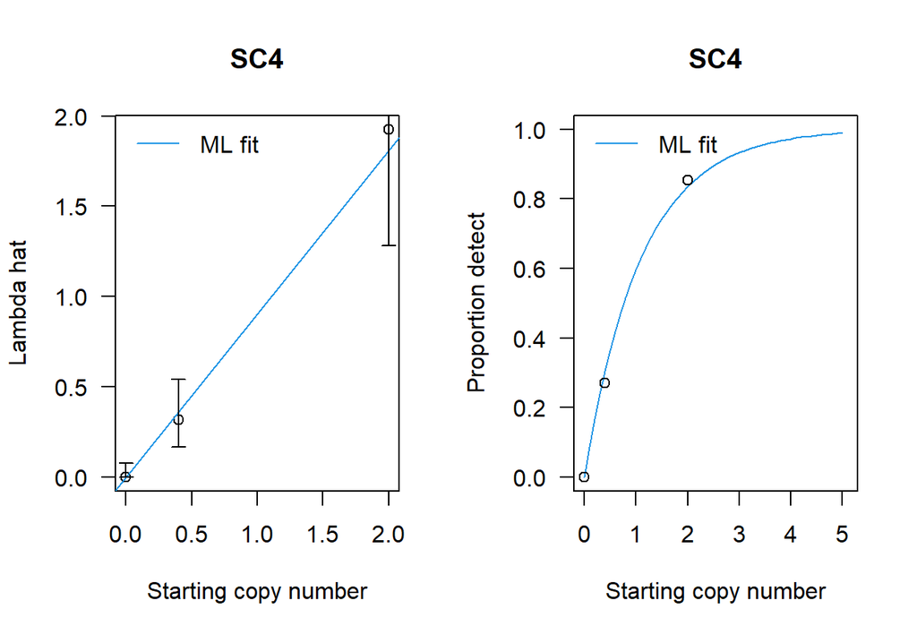

```
##
##
##
##
##  SC4
## Convergence= 0
##      Estimate Std.Err Z value  Pr(>z)
## beta    0.904   0.136    6.66 2.8e-11 ***
## ---
## Signif. codes:  0 '***' 0.001 '**' 0.01 '*' 0.05 '.' 0.1 ' ' 1
## LLR test stat= 0.365632 , df=  2 , p-value= 0.8329214
```

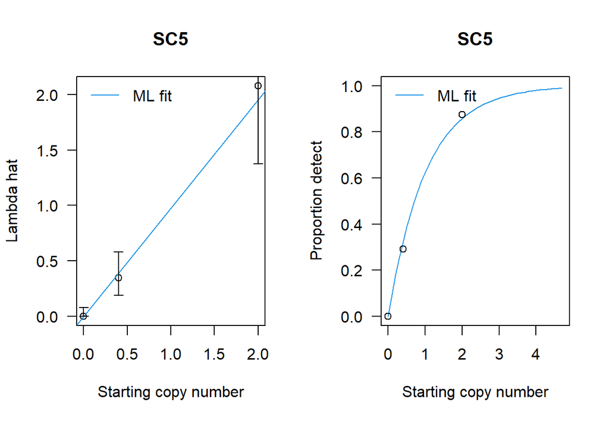

```
##
##
##
##
##  SC5
## Convergence= 0
##      Estimate Std.Err Z value  Pr(>z)
## beta    0.977   0.146    6.68 2.3e-11 ***
## ---
## Signif. codes:  0 '***' 0.001 '**' 0.01 '*' 0.05 '.' 0.1 ' ' 1
## LLR test stat= 0.3401212 , df=  2 , p-value= 0.8436137
```

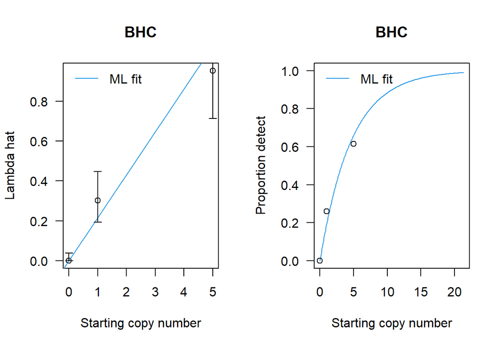

```
##
##
##
##
##  BHC
## Convergence= 0
##      Estimate Std.Err Z value Pr(>z)
## beta   0.2156  0.0243    8.86 <2e-16 ***
## ---
## Signif. codes:  0 '***' 0.001 '**' 0.01 '*' 0.05 '.' 0.1 ' ' 1
## LLR test stat= 3.368959 , df=  2 , p-value= 0.1855409
```

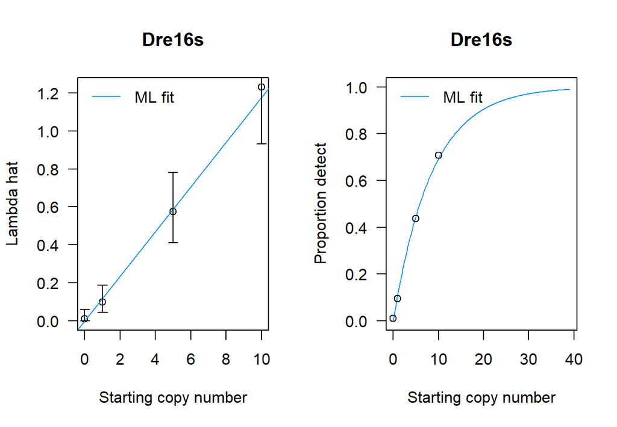

```
##
##
##
##
##  Dre16s
## Convergence= 0
##      Estimate Std.Err Z value Pr(>z)
## beta   0.1177  0.0112    10.5 <2e-16 ***
## ---
## Signif. codes:  0 '***' 0.001 '**' 0.01 '*' 0.05 '.' 0.1 ' ' 1
## LLR test stat= 0.450349 , df=  3 , p-value= 0.929656
##
## Too few values for  SS
```

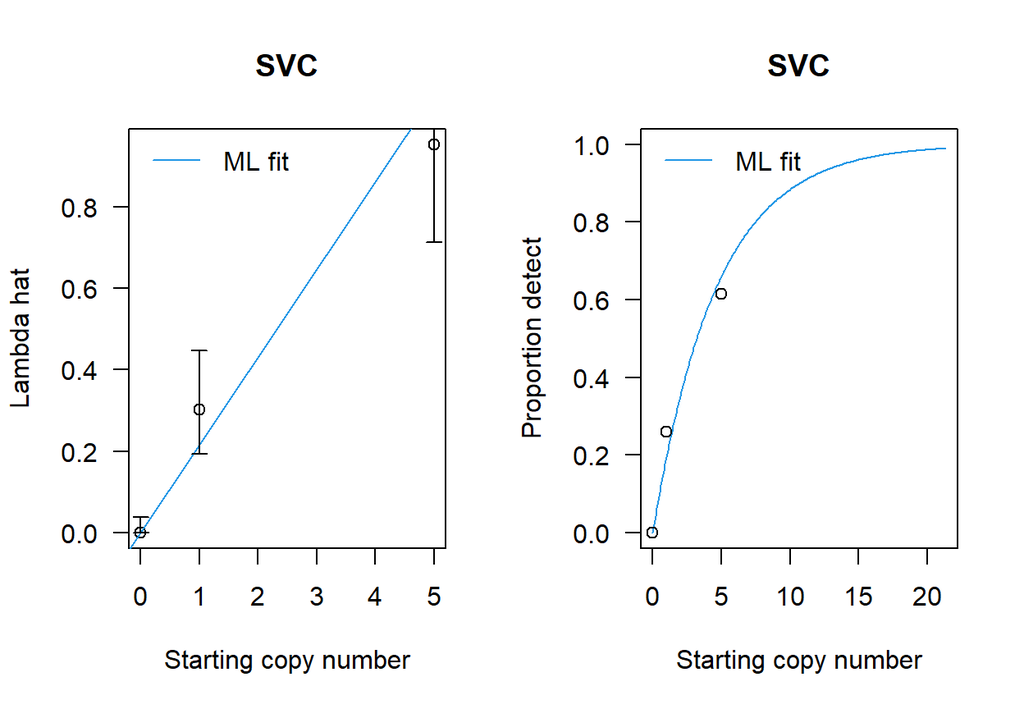

```
##
##
##
##
##  SVC
## Convergence= 0
##      Estimate Std.Err Z value Pr(>z)
## beta   0.2156  0.0243    8.86 <2e-16 ***
## ---
## Signif. codes:  0 '***' 0.001 '**' 0.01 '*' 0.05 '.' 0.1 ' ' 1
## LLR test stat= 3.368959 , df=  2 , p-value= 0.1855409
```

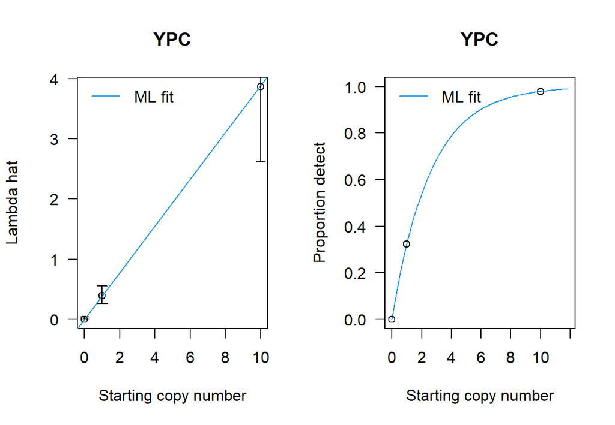

```
##
##
##
##
##  YPC
## Convergence= 0
##      Estimate Std.Err Z value  Pr(>z)
## beta   0.3885  0.0497    7.81 5.7e-15 ***
## ---
## Signif. codes:  0 '***' 0.001 '**' 0.01 '*' 0.05 '.' 0.1 ' ' 1
## LLR test stat= 0.0008171872 , df=  2 , p-value= 0.9995915
```

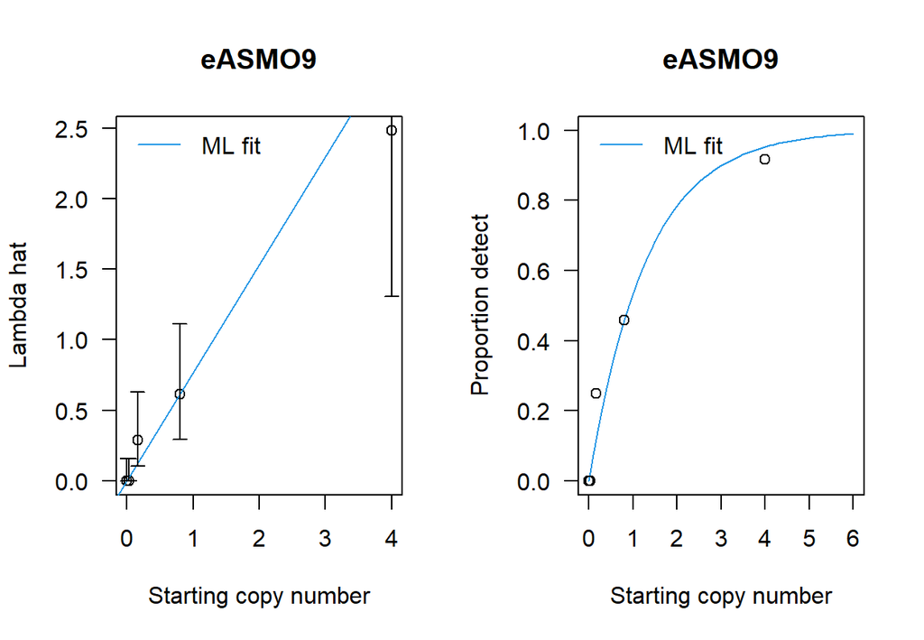

```
##
##
##
##
##  eASMO9
## Convergence= 0
##      Estimate Std.Err Z value  Pr(>z)
## beta    0.767   0.147    5.22 1.8e-07 ***
## ---
## Signif. codes:  0 '***' 0.001 '**' 0.01 '*' 0.05 '.' 0.1 ' ' 1
## LLR test stat= 5.106559 , df=  4 , p-value= 0.2765376
```

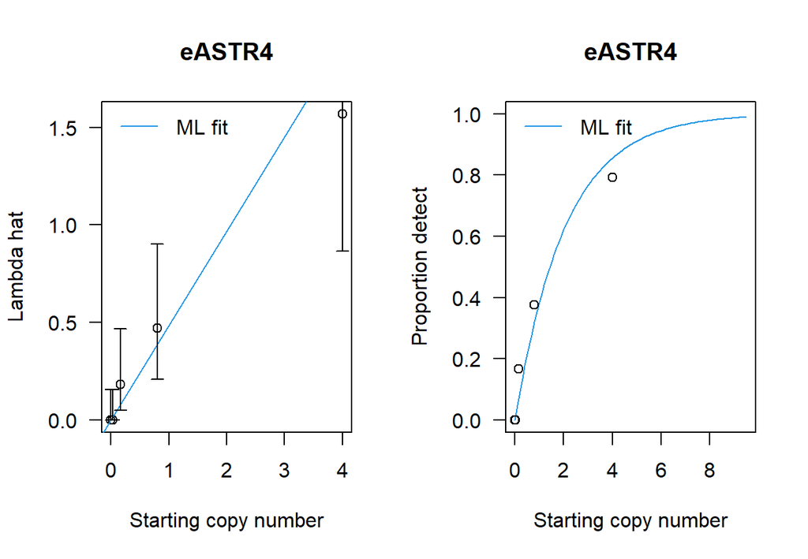

```
##
##
##
##
##  eASTR4
## Convergence= 0
##      Estimate Std.Err Z value  Pr(>z)
## beta   0.4842  0.0933    5.19 2.1e-07 ***
## ---
## Signif. codes:  0 '***' 0.001 '**' 0.01 '*' 0.05 '.' 0.1 ' ' 1
## LLR test stat= 4.017301 , df=  4 , p-value= 0.4036694
```

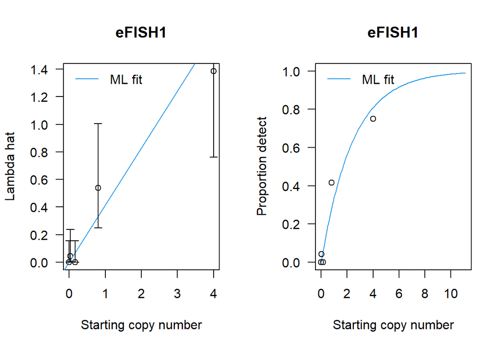

```
##
##
##
##
##  eFISH1
## Convergence= 0
##      Estimate Std.Err Z value  Pr(>z)
## beta   0.4139  0.0823    5.03 4.9e-07 ***
## ---
## Signif. codes:  0 '***' 0.001 '**' 0.01 '*' 0.05 '.' 0.1 ' ' 1
## LLR test stat= 6.63572 , df=  4 , p-value= 0.1564373
```

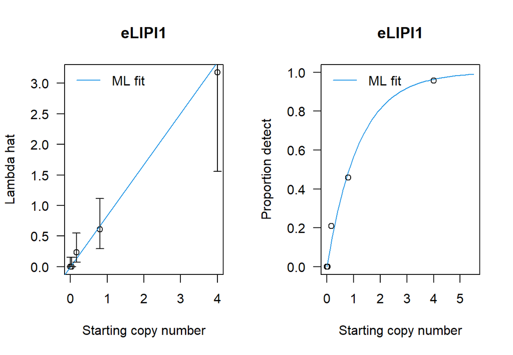

```
##
##
##
##
##  eLIPI1
## Convergence= 0
##      Estimate Std.Err Z value  Pr(>z)
## beta    0.836   0.166    5.03 4.8e-07 ***
## ---
## Signif. codes:  0 '***' 0.001 '**' 0.01 '*' 0.05 '.' 0.1 ' ' 1
## LLR test stat= 2.691805 , df=  4 , p-value= 0.6106493
```